# Association Rule

2020-08-20

## **연관규칙**(Association Analysis, 장바구니 분석)

하나의 거래나 사건에 포함된 항목 간의 관련성을 파악하여

둘 이상의 항목들로 구성된 규칙을 도출하는 탐색적 분석방법

규칙이나 패턴을 찾는 것이 핵심

레이블이 없으므로 비지도학습의 일종

평가 메트릭: 지지도(Support), 신뢰도(Confidence), 향상도(Lift)

- 지지도: A,B가 동시에 포함된 거래 수 / 전체 거래 수
- 신뢰도: A,B가 동시에 포함된 거래 수 / A를 포함하는 거래 수
- 향상도: A,B가 동시에 포함된 거래 수 / [(A를 포함하는 거래 수)*(B를 포함하는 거래 수)]

  = 신뢰도 / B의 지지도

#### 활용분야

대형마트, 백화점, 쇼핑몰 등에서 고객의 장바구니에 들어있는

품목 간의 관계를 분석 –> 마케팅 활용

#### 특징

- 거래사실이 기록된 트랜잭션 형식의 데이터셋을 이용
- 사건과 사건의 연관성(뻔한 패턴을 의미하지 않음) –> 키보드-마우스 이런거 말고 기저귀-맥주

#### 절차

1. 거래내역 데이터를 이용하여 트랜잭션 객체 생성
2. item과 transaction 관찰
3. metrics 활용 rules 발견
4. 결과 시각화
5. 결과 해석

#### 해석 방법

- 지지율이 낮다: 해당 조합의 거래 수가 적다
- 신뢰도가 낮다: A 상품 구매 시 B 상품을 함께 구매하는 거래 수가 적다
- 향상도: (==1)상품 간의 관계는 독립적, (>=1)양의 상관관계, (<=1)음의 상관관계

  ```
  arules::apriori()

  특이 자료구조(transaction) 생성

  모든 가능한 조합들에 대한 규칙(지지도, 신뢰도, 향상도)을 생성

  규칙을 확인한 후 inspect()
  ```

```r
library(arules)
```

```r
library(arulesViz)
# 1. file load: transaction 객체 생성
transac <- arules::read.transactions("data\\tran.txt",
                                     format="basket", sep=",")
transac
```

```
## transactions in sparse format with
##  6 transactions (rows) and
##  5 items (columns)
```

```r
# 2. transaction 데이터 보기: inspect()
arules::inspect(transac)  # lhs(left-hand side), rhs(right-hand side)
```

```
##     items
## [1] {라면,맥주,우유}
## [2] {고기,라면,우유}
## [3] {고기,과일,라면}
## [4] {고기,맥주,우유}
## [5] {고기,라면,우유}
## [6] {과일,우유}
```

```r
# 3. 규칙 조사: apriori()
insight <- arules::apriori(transac, parameter=list(supp=0.3, conf=0.1))
```

```
## Apriori
##
## Parameter specification:
##      confidence minval smax arem aval originalSupport maxtime support minlen
##      maxlen target ext
##  [ reached 'max' / getOption("max.print") -- omitted 1 rows ]
##
## Algorithmic control:
##  filter tree heap memopt load sort verbose
##     0.1 TRUE TRUE  FALSE TRUE    2    TRUE
##
## Absolute minimum support count: 1
##
## set item appearances ...[0 item(s)] done [0.00s].
## set transactions ...[5 item(s), 6 transaction(s)] done [0.00s].
## sorting and recoding items ... [5 item(s)] done [0.00s].
## creating transaction tree ... done [0.00s].
## checking subsets of size 1 2 3 done [0.00s].
## writing ... [16 rule(s)] done [0.00s].
## creating S4 object  ... done [0.00s].
```

```r
inspect(insight)
```

```
##     lhs    rhs    support   confidence coverage lift count
## [1] {}  => {과일} 0.3333333 0.3333333  1        1    2
##  [ reached 'max' / getOption("max.print") -- omitted 15 rows ]
```

```r
# 4. 해석
# 1 ~ 5행: 전체 6트랜잭션 중
#   과일 포함 2,
#   맥주 포함 2
#   고기 포함 4
#   라면 포함 4
#   우유 포함 5
# 6 ~ 7행: 맥주와 우유를 동시에 산 트랜잭션은 2 (support=2/6=0.33)
# 그 중 맥주를 산 사람이 우유를 산 트랜잭션은 conf=2/2
# 반면, 우유를 산 사람 중 맥주를 산 트랜잭션은 conf=2/5
# 향상도 > 1 이므로 맥주와 우유는 양의 상관관계를 가짐

# 5. 기타 확인사항
summary(insight)
```

```
## set of 16 rules
##
## rule length distribution (lhs + rhs):sizes
## 1 2 3
## 5 8 3
##
##    Min. 1st Qu.  Median    Mean 3rd Qu.    Max.
##   1.000   1.000   2.000   1.875   2.000   3.000
##
## summary of quality measures:
##     support         confidence        coverage           lift
##  Min.   :0.3333   Min.   :0.3333   Min.   :0.3333   Min.   :0.800
##  1st Qu.:0.3333   1st Qu.:0.6000   1st Qu.:0.6250   1st Qu.:0.900
##      count
##  Min.   :2.000
##  1st Qu.:2.000
##  [ getOption("max.print") 에 도달했습니다 -- 4 행들을 생략합니다 ]
##
## mining info:
##     data ntransactions support confidence
##  transac             6     0.3        0.1
```

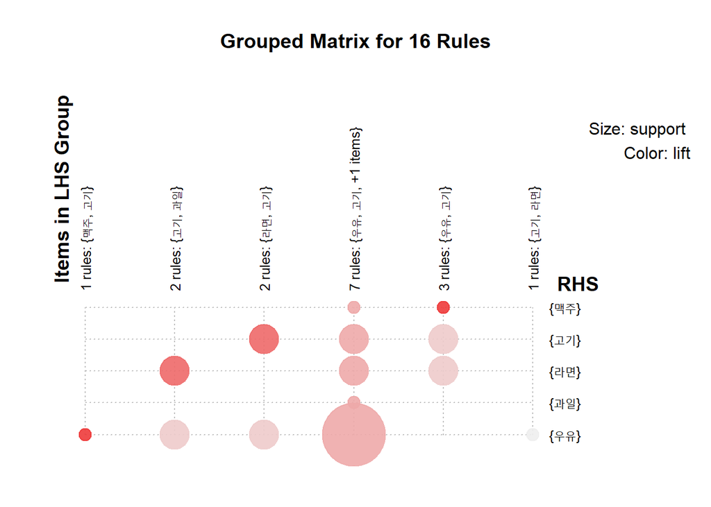

```r
# 6. plot
plot(insight, method="grouped")
```

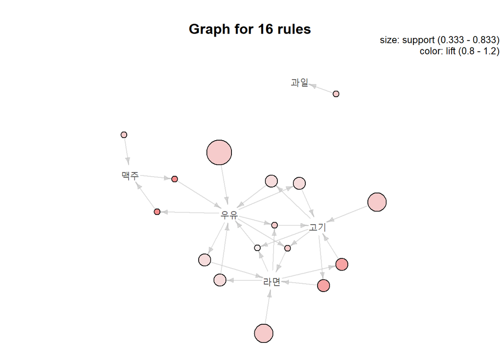

```r
plot(insight, method="graph")#, control = list(type="items"))
```

```r
library(dplyr)
# Groceries 데이터셋
data(Groceries) # arules의 데이터셋
str(Groceries)
```

```
## Formal class 'transactions' [package "arules"] with 3 slots
##   ..@ data       :Formal class 'ngCMatrix' [package "Matrix"] with 5 slots
##   .. .. ..@ i       : int [1:43367] 13 60 69 78 14 29 98 24 15 29 ...
##   .. .. ..@ p       : int [1:9836] 0 4 7 8 12 16 21 22 27 28 ...
##   .. .. ..@ Dim     : int [1:2] 169 9835
##   .. .. ..@ Dimnames:List of 2
##   .. .. .. ..$ : NULL
##   .. .. .. ..$ : NULL
##   .. .. ..@ factors : list()
##   ..@ itemInfo   :'data.frame':  169 obs. of  3 variables:
##   .. ..$ labels: chr [1:169] "frankfurter" "sausage" "liver loaf" "ham" ...
##   .. ..$ level2: Factor w/ 55 levels "baby food","bags",..: 44 44 44 44 44 44 44 42 42 41 ...
##   .. ..$ level1: Factor w/ 10 levels "canned food",..: 6 6 6 6 6 6 6 6 6 6 ...
##   ..@ itemsetInfo:'data.frame':  0 obs. of  0 variables
```

```r
Groceries
```

```
## transactions in sparse format with
##  9835 transactions (rows) and
##  169 items (columns)
```

```r
# data.frame으로 변환
Groceries.df <- as(Groceries, "data.frame")
head(Groceries.df)
```

```
##                                                                   items
## 1              {citrus fruit,semi-finished bread,margarine,ready soups}
## 2                                        {tropical fruit,yogurt,coffee}
## 3                                                          {whole milk}
## 4                         {pip fruit,yogurt,cream cheese ,meat spreads}
## 5 {other vegetables,whole milk,condensed milk,long life bakery product}
## 6                      {whole milk,butter,yogurt,rice,abrasive cleaner}
```

```r
# 지지도 0.001, 신뢰도 0.8 이상을 만족하는 규칙 찾기
rules <- apriori(Groceries, parameter=list(supp=0.001, conf=0.8))
```

```
## Apriori
##
## Parameter specification:
##      confidence minval smax arem aval originalSupport maxtime support minlen
##      maxlen target ext
##  [ reached 'max' / getOption("max.print") -- omitted 1 rows ]
##
## Algorithmic control:
##  filter tree heap memopt load sort verbose
##     0.1 TRUE TRUE  FALSE TRUE    2    TRUE
##
## Absolute minimum support count: 9
##
## set item appearances ...[0 item(s)] done [0.00s].
## set transactions ...[169 item(s), 9835 transaction(s)] done [0.00s].
## sorting and recoding items ... [157 item(s)] done [0.00s].
## creating transaction tree ... done [0.00s].
## checking subsets of size 1 2 3 4 5 6 done [0.01s].
## writing ... [410 rule(s)] done [0.00s].
## creating S4 object  ... done [0.00s].
```

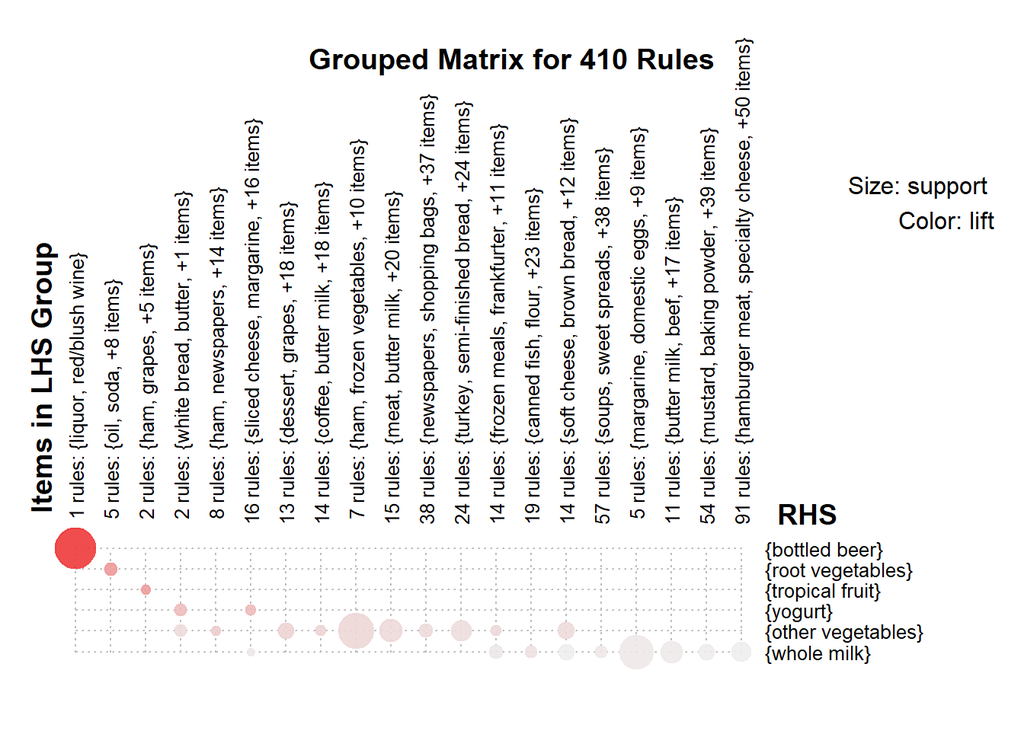

```r
# 규칙을 구성하는 lhs -> rhs의 item 빈도 수 보기
plot(rules, method="grouped")
```

```r
# conf 기준 내림차순으로 규칙 정렬
rules <- arules::sort(rules, decreasing=T, by="confidence")
inspect(rules)
```

```
##       lhs                           rhs                    support confidence    coverage      lift count
## [1]   {rice,
##        sugar}                    => {whole milk}       0.001220132  1.0000000 0.001220132  3.913649    12
## [2]   {canned fish,
##        hygiene articles}         => {whole milk}       0.001118454  1.0000000 0.001118454  3.913649    11
## [3]   {root vegetables,
##        butter,
##        rice}                     => {whole milk}       0.001016777  1.0000000 0.001016777  3.913649    10
## [4]   {root vegetables,
##        whipped/sour cream,
##        flour}                    => {whole milk}       0.001728521  1.0000000 0.001728521  3.913649    17
## [5]   {butter,
##        soft cheese,
##        domestic eggs}            => {whole milk}       0.001016777  1.0000000 0.001016777  3.913649    10
## [6]   {citrus fruit,
##        root vegetables,
##        soft cheese}              => {other vegetables} 0.001016777  1.0000000 0.001016777  5.168156    10
## [7]   {pip fruit,
##        butter,
##        hygiene articles}         => {whole milk}       0.001016777  1.0000000 0.001016777  3.913649    10
## [8]   {root vegetables,
##        whipped/sour cream,
##        hygiene articles}         => {whole milk}       0.001016777  1.0000000 0.001016777  3.913649    10
## [9]   {pip fruit,
##        root vegetables,
##        hygiene articles}         => {whole milk}       0.001016777  1.0000000 0.001016777  3.913649    10
## [10]  {cream cheese ,
##        domestic eggs,
##        sugar}                    => {whole milk}       0.001118454  1.0000000 0.001118454  3.913649    11
## [11]  {curd,
##        domestic eggs,
##        sugar}                    => {whole milk}       0.001016777  1.0000000 0.001016777  3.913649    10
## [12]  {cream cheese ,
##        domestic eggs,
##        napkins}                  => {whole milk}       0.001118454  1.0000000 0.001118454  3.913649    11
## [13]  {pip fruit,
##        whipped/sour cream,
##        brown bread}              => {other vegetables} 0.001118454  1.0000000 0.001118454  5.168156    11
## [14]  {tropical fruit,
##        grapes,
```

[output cut: 1311 more lines]

```
##        citrus fruit,
##        other vegetables,
##        whipped/sour cream}       => {whole milk}       0.001220132  0.8000000 0.001525165  3.130919    12
## [408] {sausage,
##        citrus fruit,
##        whole milk,
##        whipped/sour cream}       => {other vegetables} 0.001220132  0.8000000 0.001525165  4.134524    12
## [409] {citrus fruit,
##        tropical fruit,
##        yogurt,
##        whipped/sour cream}       => {whole milk}       0.001220132  0.8000000 0.001525165  3.130919    12
## [410] {tropical fruit,
##        root vegetables,
##        whipped/sour cream,
##        rolls/buns}               => {other vegetables} 0.001220132  0.8000000 0.001525165  4.134524    12
```

```r
inspect(head(rules,10))
```

```
##      lhs                     rhs                    support confidence    coverage     lift count
## [1]  {rice,
##       sugar}              => {whole milk}       0.001220132          1 0.001220132 3.913649    12
## [2]  {canned fish,
##       hygiene articles}   => {whole milk}       0.001118454          1 0.001118454 3.913649    11
## [3]  {root vegetables,
##       butter,
##       rice}               => {whole milk}       0.001016777          1 0.001016777 3.913649    10
## [4]  {root vegetables,
##       whipped/sour cream,
##       flour}              => {whole milk}       0.001728521          1 0.001728521 3.913649    17
## [5]  {butter,
##       soft cheese,
##       domestic eggs}      => {whole milk}       0.001016777          1 0.001016777 3.913649    10
## [6]  {citrus fruit,
##       root vegetables,
##       soft cheese}        => {other vegetables} 0.001016777          1 0.001016777 5.168156    10
## [7]  {pip fruit,
##       butter,
##       hygiene articles}   => {whole milk}       0.001016777          1 0.001016777 3.913649    10
## [8]  {root vegetables,
##       whipped/sour cream,
##       hygiene articles}   => {whole milk}       0.001016777          1 0.001016777 3.913649    10
## [9]  {pip fruit,
##       root vegetables,
##       hygiene articles}   => {whole milk}       0.001016777          1 0.001016777 3.913649    10
## [10] {cream cheese ,
##       domestic eggs,
##       sugar}              => {whole milk}       0.001118454          1 0.001118454 3.913649    11
```

```r
# lift 기준
rules1 <- arules::sort(rules, decreasing=T, by="lift")
inspect(rules1)
```

```
##       lhs                           rhs                    support confidence    coverage      lift count
## [1]   {liquor,
##        red/blush wine}           => {bottled beer}     0.001931876  0.9047619 0.002135231 11.235269    19
## [2]   {citrus fruit,
##        other vegetables,
##        soda,
##        fruit/vegetable juice}    => {root vegetables}  0.001016777  0.9090909 0.001118454  8.340400    10
## [3]   {tropical fruit,
##        other vegetables,
##        whole milk,
##        yogurt,
##        oil}                      => {root vegetables}  0.001016777  0.9090909 0.001118454  8.340400    10
## [4]   {citrus fruit,
##        grapes,
##        fruit/vegetable juice}    => {tropical fruit}   0.001118454  0.8461538 0.001321810  8.063879    11
## [5]   {other vegetables,
##        whole milk,
##        yogurt,
##        rice}                     => {root vegetables}  0.001321810  0.8666667 0.001525165  7.951182    13
## [6]   {tropical fruit,
##        other vegetables,
##        whole milk,
##        oil}                      => {root vegetables}  0.001321810  0.8666667 0.001525165  7.951182    13
## [7]   {ham,
##        pip fruit,
##        other vegetables,
##        yogurt}                   => {tropical fruit}   0.001016777  0.8333333 0.001220132  7.941699    10
## [8]   {beef,
##        citrus fruit,
##        tropical fruit,
##        other vegetables}         => {root vegetables}  0.001016777  0.8333333 0.001220132  7.645367    10
## [9]   {root vegetables,
##        butter,
##        cream cheese }            => {yogurt}           0.001016777  0.9090909 0.001118454  6.516698    10
## [10]  {tropical fruit,
##        whole milk,
##        butter,
##        sliced cheese}            => {yogurt}           0.001016777  0.9090909 0.001118454  6.516698    10
## [11]  {other vegetables,
##        curd,
```

[output cut: 1311 more lines]

```
##        butter,
##        yogurt,
##        whipped/sour cream}       => {whole milk}       0.001220132  0.8000000 0.001525165  3.130919    12
## [408] {other vegetables,
##        butter,
##        whipped/sour cream,
##        rolls/buns}               => {whole milk}       0.001220132  0.8000000 0.001525165  3.130919    12
## [409] {sausage,
##        citrus fruit,
##        other vegetables,
##        whipped/sour cream}       => {whole milk}       0.001220132  0.8000000 0.001525165  3.130919    12
## [410] {citrus fruit,
##        tropical fruit,
##        yogurt,
##        whipped/sour cream}       => {whole milk}       0.001220132  0.8000000 0.001525165  3.130919    12
```

```r
inspect(head(rules1,10))
```

```
##      lhs                        rhs                   support confidence    coverage      lift count
## [1]  {liquor,
##       red/blush wine}        => {bottled beer}    0.001931876  0.9047619 0.002135231 11.235269    19
## [2]  {citrus fruit,
##       other vegetables,
##       soda,
##       fruit/vegetable juice} => {root vegetables} 0.001016777  0.9090909 0.001118454  8.340400    10
## [3]  {tropical fruit,
##       other vegetables,
##       whole milk,
##       yogurt,
##       oil}                   => {root vegetables} 0.001016777  0.9090909 0.001118454  8.340400    10
## [4]  {citrus fruit,
##       grapes,
##       fruit/vegetable juice} => {tropical fruit}  0.001118454  0.8461538 0.001321810  8.063879    11
## [5]  {other vegetables,
##       whole milk,
##       yogurt,
##       rice}                  => {root vegetables} 0.001321810  0.8666667 0.001525165  7.951182    13
## [6]  {tropical fruit,
##       other vegetables,
##       whole milk,
##       oil}                   => {root vegetables} 0.001321810  0.8666667 0.001525165  7.951182    13
## [7]  {ham,
##       pip fruit,
##       other vegetables,
##       yogurt}                => {tropical fruit}  0.001016777  0.8333333 0.001220132  7.941699    10
## [8]  {beef,
##       citrus fruit,
##       tropical fruit,
##       other vegetables}      => {root vegetables} 0.001016777  0.8333333 0.001220132  7.645367    10
## [9]  {root vegetables,
##       butter,
##       cream cheese }         => {yogurt}          0.001016777  0.9090909 0.001118454  6.516698    10
## [10] {tropical fruit,
##       whole milk,
##       butter,
##       sliced cheese}         => {yogurt}          0.001016777  0.9090909 0.001118454  6.516698    10
```

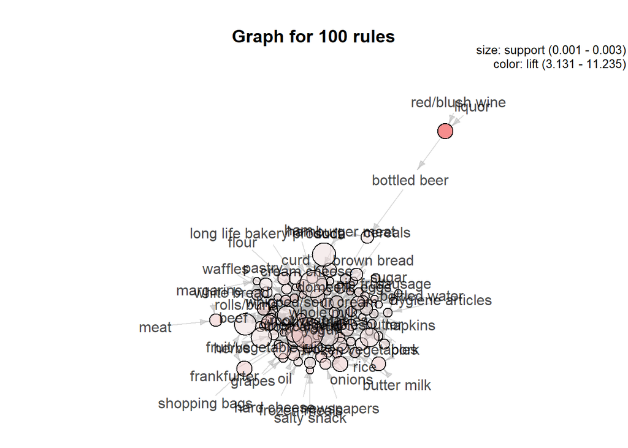

```r
# 발견된 규칙 시각화
plot(rules, method="graph")
```

```r
# 특정 상품 subset과 시각화
# 오른쪽 item이 전지분유(whole milk)인 규칙만 subset으로 작성
wmilk <- subset(rules, rhs %in% 'whole milk')
wmilk
```

```
## set of 252 rules
```

```r
inspect(head(wmilk,10))
```

```
##      lhs                     rhs              support confidence    coverage     lift count
## [1]  {rice,
##       sugar}              => {whole milk} 0.001220132          1 0.001220132 3.913649    12
## [2]  {canned fish,
##       hygiene articles}   => {whole milk} 0.001118454          1 0.001118454 3.913649    11
## [3]  {root vegetables,
##       butter,
##       rice}               => {whole milk} 0.001016777          1 0.001016777 3.913649    10
## [4]  {root vegetables,
##       whipped/sour cream,
##       flour}              => {whole milk} 0.001728521          1 0.001728521 3.913649    17
## [5]  {butter,
##       soft cheese,
##       domestic eggs}      => {whole milk} 0.001016777          1 0.001016777 3.913649    10
## [6]  {pip fruit,
##       butter,
##       hygiene articles}   => {whole milk} 0.001016777          1 0.001016777 3.913649    10
## [7]  {root vegetables,
##       whipped/sour cream,
##       hygiene articles}   => {whole milk} 0.001016777          1 0.001016777 3.913649    10
## [8]  {pip fruit,
##       root vegetables,
##       hygiene articles}   => {whole milk} 0.001016777          1 0.001016777 3.913649    10
## [9]  {cream cheese ,
##       domestic eggs,
##       sugar}              => {whole milk} 0.001118454          1 0.001118454 3.913649    11
## [10] {curd,
##       domestic eggs,
##       sugar}              => {whole milk} 0.001016777          1 0.001016777 3.913649    10
```

```r
inspect(tail(wmilk,10))
```

```
##      lhs                     rhs              support confidence    coverage     lift count
## [1]  {rolls/buns,
##       bottled beer,
##       napkins}            => {whole milk} 0.001220132        0.8 0.001525165 3.130919    12
## [2]  {whipped/sour cream,
##       domestic eggs,
##       margarine}          => {whole milk} 0.001220132        0.8 0.001525165 3.130919    12
## [3]  {citrus fruit,
##       tropical fruit,
##       butter}             => {whole milk} 0.001626843        0.8 0.002033554 3.130919    16
## [4]  {sausage,
##       pip fruit,
##       whipped/sour cream} => {whole milk} 0.001220132        0.8 0.001525165 3.130919    12
## [5]  {chicken,
##       root vegetables,
##       other vegetables,
##       domestic eggs}      => {whole milk} 0.001220132        0.8 0.001525165 3.130919    12
## [6]  {tropical fruit,
##       butter,
##       curd,
##       yogurt}             => {whole milk} 0.001220132        0.8 0.001525165 3.130919    12
## [7]  {tropical fruit,
##       butter,
##       yogurt,
##       whipped/sour cream} => {whole milk} 0.001220132        0.8 0.001525165 3.130919    12
## [8]  {other vegetables,
##       butter,
##       whipped/sour cream,
##       rolls/buns}         => {whole milk} 0.001220132        0.8 0.001525165 3.130919    12
## [9]  {sausage,
##       citrus fruit,
##       other vegetables,
##       whipped/sour cream} => {whole milk} 0.001220132        0.8 0.001525165 3.130919    12
## [10] {citrus fruit,
##       tropical fruit,
##       yogurt,
##       whipped/sour cream} => {whole milk} 0.001220132        0.8 0.001525165 3.130919    12
```

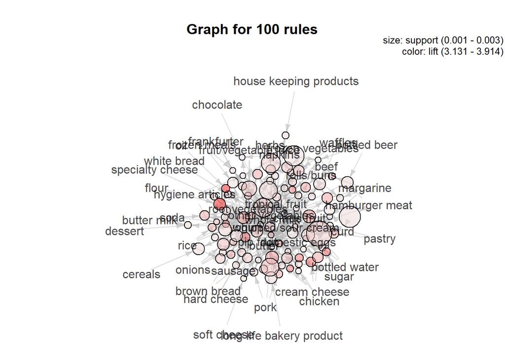

```r
plot(wmilk, method="graph")
```

```r
# 오른쪽 item이 other vegetables인 규칙만 서브셋으로 작성
oveg <- subset(rules, rhs %in% 'other vegetables')
oveg
```

```
## set of 134 rules
```

```r
inspect(head(oveg))
```

```
##     lhs                        rhs                    support confidence    coverage     lift count
## [1] {citrus fruit,
##      root vegetables,
##      soft cheese}           => {other vegetables} 0.001016777          1 0.001016777 5.168156    10
## [2] {pip fruit,
##      whipped/sour cream,
##      brown bread}           => {other vegetables} 0.001118454          1 0.001118454 5.168156    11
## [3] {tropical fruit,
##      grapes,
##      whole milk,
##      yogurt}                => {other vegetables} 0.001016777          1 0.001016777 5.168156    10
## [4] {ham,
##      tropical fruit,
##      pip fruit,
##      yogurt}                => {other vegetables} 0.001016777          1 0.001016777 5.168156    10
## [5] {ham,
##      tropical fruit,
##      pip fruit,
##      whole milk}            => {other vegetables} 0.001118454          1 0.001118454 5.168156    11
## [6] {tropical fruit,
##      butter,
##      whipped/sour cream,
##      fruit/vegetable juice} => {other vegetables} 0.001016777          1 0.001016777 5.168156    10
```

```r
# 오른쪽 item이 vegetables 단어가 포함된 규칙만 서브셋으로 작성
oveg1 <- subset(rules, rhs %pin% 'vegetables')
oveg1
```

```
## set of 139 rules
```

```r
inspect(oveg1)  # root vegetables, other vegetables
```

```
##       lhs                           rhs                    support confidence    coverage     lift count
## [1]   {citrus fruit,
##        root vegetables,
##        soft cheese}              => {other vegetables} 0.001016777  1.0000000 0.001016777 5.168156    10
## [2]   {pip fruit,
##        whipped/sour cream,
##        brown bread}              => {other vegetables} 0.001118454  1.0000000 0.001118454 5.168156    11
## [3]   {tropical fruit,
##        grapes,
##        whole milk,
##        yogurt}                   => {other vegetables} 0.001016777  1.0000000 0.001016777 5.168156    10
## [4]   {ham,
##        tropical fruit,
##        pip fruit,
##        yogurt}                   => {other vegetables} 0.001016777  1.0000000 0.001016777 5.168156    10
## [5]   {ham,
##        tropical fruit,
##        pip fruit,
##        whole milk}               => {other vegetables} 0.001118454  1.0000000 0.001118454 5.168156    11
## [6]   {tropical fruit,
##        butter,
##        whipped/sour cream,
##        fruit/vegetable juice}    => {other vegetables} 0.001016777  1.0000000 0.001016777 5.168156    10
## [7]   {whole milk,
##        rolls/buns,
##        soda,
##        newspapers}               => {other vegetables} 0.001016777  1.0000000 0.001016777 5.168156    10
## [8]   {citrus fruit,
##        tropical fruit,
##        root vegetables,
##        whipped/sour cream}       => {other vegetables} 0.001220132  1.0000000 0.001220132 5.168156    12
## [9]   {root vegetables,
##        whole milk,
##        yogurt,
##        oil}                      => {other vegetables} 0.001423488  0.9333333 0.001525165 4.823612    14
## [10]  {citrus fruit,
##        tropical fruit,
##        root vegetables,
##        whole milk,
##        yogurt}                   => {other vegetables} 0.001423488  0.9333333 0.001525165 4.823612    14
```

[output cut: 414 more lines]

```
##        whole milk,
##        yogurt,
##        fruit/vegetable juice}    => {other vegetables} 0.002033554  0.8000000 0.002541942 4.134524    20
## [137] {tropical fruit,
##        pip fruit,
##        whole milk,
##        whipped/sour cream}       => {other vegetables} 0.001626843  0.8000000 0.002033554 4.134524    16
## [138] {sausage,
##        citrus fruit,
##        whole milk,
##        whipped/sour cream}       => {other vegetables} 0.001220132  0.8000000 0.001525165 4.134524    12
## [139] {tropical fruit,
##        root vegetables,
##        whipped/sour cream,
##        rolls/buns}               => {other vegetables} 0.001220132  0.8000000 0.001525165 4.134524    12
```

```r
# 왼쪽 item이 butter 또는 yogurt인 규칙만 서브셋으로 작성
butter_yogurt <- subset(rules, lhs %in% c('butter', 'yogurt'))
butter_yogurt
```

```
## set of 175 rules
```

```r
inspect(head(butter_yogurt))
```

```
##     lhs                   rhs                    support confidence    coverage     lift count
## [1] {root vegetables,
##      butter,
##      rice}             => {whole milk}       0.001016777          1 0.001016777 3.913649    10
## [2] {butter,
##      soft cheese,
##      domestic eggs}    => {whole milk}       0.001016777          1 0.001016777 3.913649    10
## [3] {pip fruit,
##      butter,
##      hygiene articles} => {whole milk}       0.001016777          1 0.001016777 3.913649    10
## [4] {tropical fruit,
##      grapes,
##      whole milk,
##      yogurt}           => {other vegetables} 0.001016777          1 0.001016777 5.168156    10
## [5] {ham,
##      tropical fruit,
##      pip fruit,
##      yogurt}           => {other vegetables} 0.001016777          1 0.001016777 5.168156    10
## [6] {tropical fruit,
##      root vegetables,
##      yogurt,
##      oil}              => {whole milk}       0.001118454          1 0.001118454 3.913649    11
```

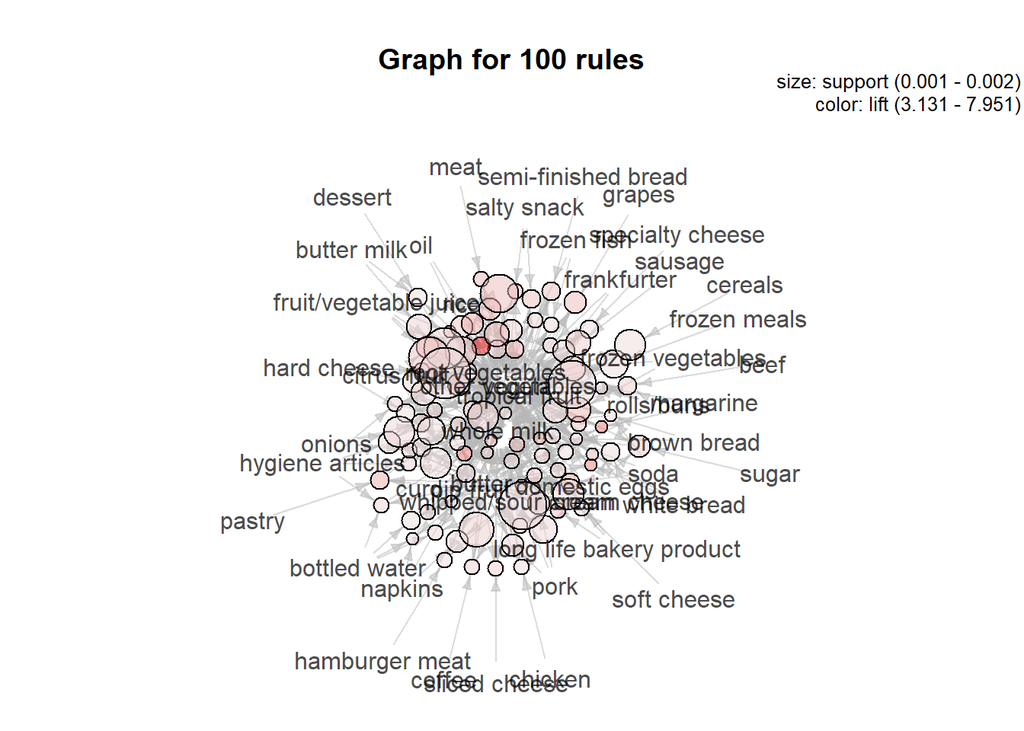

```r
plot(butter_yogurt, method="graph")
```

```r
butter_yogurt1 <- subset(butter_yogurt, confidence>=0.9 & lift>=5)
inspect(head(butter_yogurt1))
```

```
##     lhs                        rhs                    support confidence    coverage     lift count
## [1] {tropical fruit,
##      grapes,
##      whole milk,
##      yogurt}                => {other vegetables} 0.001016777  1.0000000 0.001016777 5.168156    10
## [2] {ham,
##      tropical fruit,
##      pip fruit,
##      yogurt}                => {other vegetables} 0.001016777  1.0000000 0.001016777 5.168156    10
## [3] {tropical fruit,
##      butter,
##      whipped/sour cream,
##      fruit/vegetable juice} => {other vegetables} 0.001016777  1.0000000 0.001016777 5.168156    10
## [4] {root vegetables,
##      butter,
##      cream cheese }         => {yogurt}           0.001016777  0.9090909 0.001118454 6.516698    10
## [5] {tropical fruit,
##      whole milk,
##      butter,
##      sliced cheese}         => {yogurt}           0.001016777  0.9090909 0.001118454 6.516698    10
## [6] {tropical fruit,
##      other vegetables,
##      butter,
##      white bread}           => {yogurt}           0.001016777  0.9090909 0.001118454 6.516698    10
```

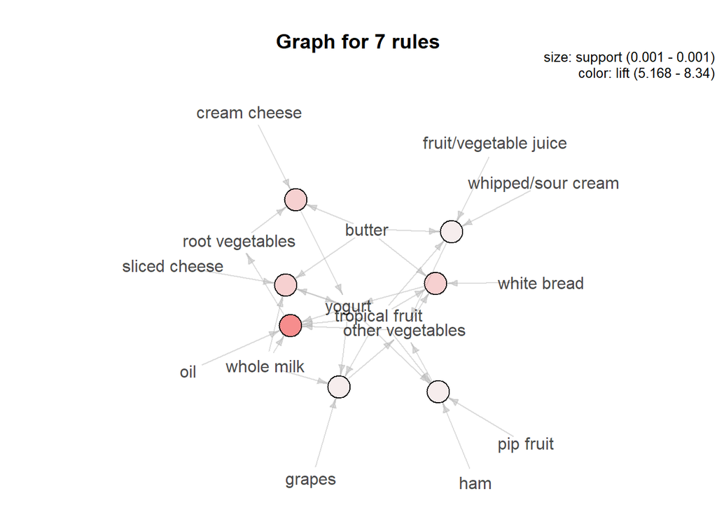

```r
plot(butter_yogurt1, method="graph")
```

```r
# cf) 세부 거래품목 빈도확인 itemFrequency
sort(arules::itemFrequency(Groceries, type="absolute"), decreasing=T)
```

```
##       whole milk other vegetables       rolls/buns             soda
##             2513             1903             1809             1715
##           yogurt    bottled water  root vegetables   tropical fruit
##             1372             1087             1072             1032
##    shopping bags          sausage
##              969              924
##  [ reached getOption("max.print") -- omitted 159 entries ]
```

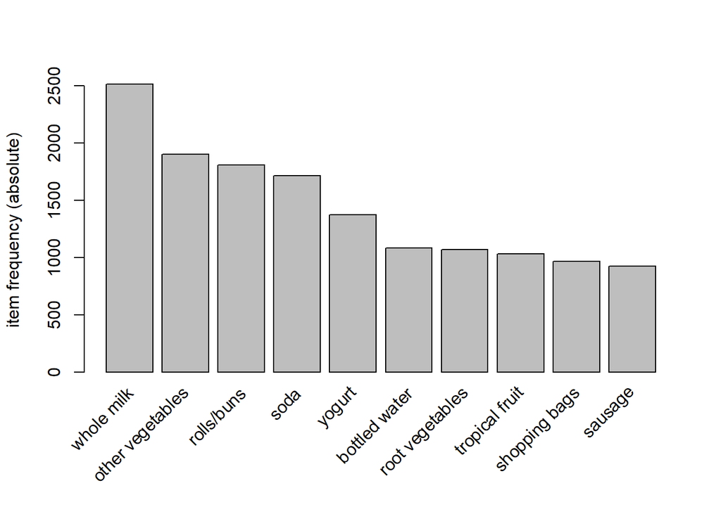

```r
arules::itemFrequencyPlot(Groceries, topN=10, type="absolute")
```

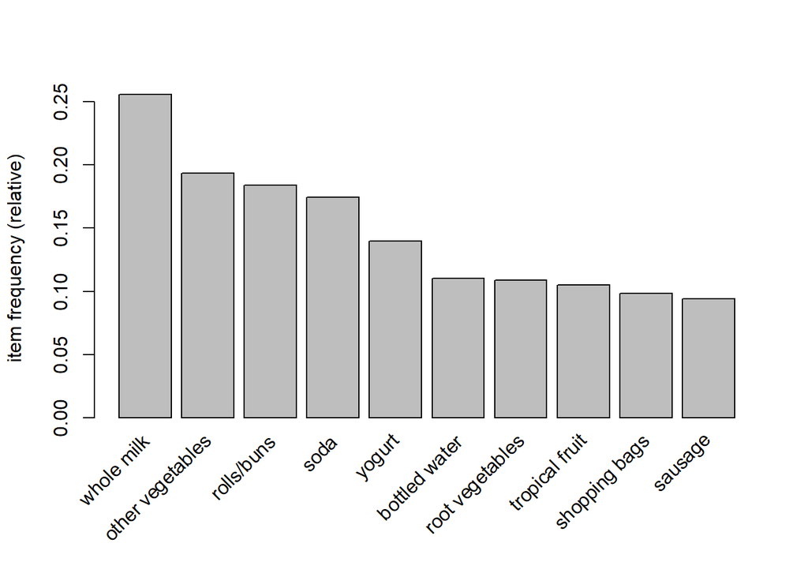

```r
arules::itemFrequencyPlot(Groceries, topN=10, type="relative")
```

```r
groc <- apriori(Groceries, parameter=list(supp=0.005, conf=0.5, minlen=2))
```

```
## Apriori
##
## Parameter specification:
##      confidence minval smax arem aval originalSupport maxtime support minlen
##      maxlen target ext
##  [ reached 'max' / getOption("max.print") -- omitted 1 rows ]
##
## Algorithmic control:
##  filter tree heap memopt load sort verbose
##     0.1 TRUE TRUE  FALSE TRUE    2    TRUE
##
## Absolute minimum support count: 49
##
## set item appearances ...[0 item(s)] done [0.00s].
## set transactions ...[169 item(s), 9835 transaction(s)] done [0.00s].
## sorting and recoding items ... [120 item(s)] done [0.00s].
## creating transaction tree ... done [0.00s].
## checking subsets of size 1 2 3 4 done [0.00s].
## writing ... [120 rule(s)] done [0.00s].
## creating S4 object  ... done [0.00s].
```

```r
inspect(groc)
```

```
##       lhs                           rhs                    support confidence    coverage     lift count
## [1]   {baking powder}            => {whole milk}       0.009252669  0.5229885 0.017691917 2.046793    91
## [2]   {other vegetables,
##        oil}                      => {whole milk}       0.005083884  0.5102041 0.009964413 1.996760    50
## [3]   {root vegetables,
##        onions}                   => {other vegetables} 0.005693950  0.6021505 0.009456024 3.112008    56
## [4]   {onions,
##        whole milk}               => {other vegetables} 0.006609049  0.5462185 0.012099644 2.822942    65
## [5]   {other vegetables,
##        hygiene articles}         => {whole milk}       0.005185562  0.5425532 0.009557702 2.123363    51
## [6]   {other vegetables,
##        sugar}                    => {whole milk}       0.006304016  0.5849057 0.010777834 2.289115    62
## [7]   {other vegetables,
##        long life bakery product} => {whole milk}       0.005693950  0.5333333 0.010676157 2.087279    56
## [8]   {yogurt,
##        cream cheese }            => {whole milk}       0.006609049  0.5327869 0.012404677 2.085141    65
## [9]   {chicken,
##        root vegetables}          => {other vegetables} 0.005693950  0.5233645 0.010879512 2.704829    56
## [10]  {chicken,
##        root vegetables}          => {whole milk}       0.005998983  0.5514019 0.010879512 2.157993    59
## [11]  {chicken,
##        rolls/buns}               => {whole milk}       0.005287239  0.5473684 0.009659380 2.142208    52
## [12]  {yogurt,
##        coffee}                   => {whole milk}       0.005083884  0.5208333 0.009761057 2.038359    50
## [13]  {root vegetables,
##        frozen vegetables}        => {other vegetables} 0.006100661  0.5263158 0.011591256 2.720082    60
## [14]  {root vegetables,
##        frozen vegetables}        => {whole milk}       0.006202339  0.5350877 0.011591256 2.094146    61
## [15]  {frozen vegetables,
##        rolls/buns}               => {whole milk}       0.005083884  0.5000000 0.010167768 1.956825    50
## [16]  {other vegetables,
##        frozen vegetables}        => {whole milk}       0.009659380  0.5428571 0.017793594 2.124552    95
## [17]  {beef,
##        yogurt}                   => {whole milk}       0.006100661  0.5217391 0.011692933 2.041904    60
## [18]  {beef,
##        rolls/buns}               => {whole milk}       0.006812405  0.5000000 0.013624809 1.956825    67
## [19]  {curd,
##        whipped/sour cream}       => {whole milk}       0.005897306  0.5631068 0.010472801 2.203802    58
## [20]  {tropical fruit,
##        curd}                     => {yogurt}           0.005287239  0.5148515 0.010269446 3.690645    52
```

[output cut: 206 more lines]

```
## [116] {tropical fruit,
##        whole milk,
##        yogurt}                   => {other vegetables} 0.007625826  0.5033557 0.015149975 2.601421    75
## [117] {root vegetables,
##        other vegetables,
##        yogurt}                   => {whole milk}       0.007829181  0.6062992 0.012913066 2.372842    77
## [118] {root vegetables,
##        whole milk,
##        yogurt}                   => {other vegetables} 0.007829181  0.5384615 0.014539908 2.782853    77
## [119] {root vegetables,
##        other vegetables,
##        rolls/buns}               => {whole milk}       0.006202339  0.5083333 0.012201322 1.989438    61
## [120] {other vegetables,
##        yogurt,
##        rolls/buns}               => {whole milk}       0.005998983  0.5221239 0.011489578 2.043410    59
```